# Unit 6 Exercises

Your Name

05 February, 2024

**Question 1.** Every day Alana, an amateur [transcendentalist](https://en.wikipedia.org/wiki/Transcendentalism) and photographer, walks by a pond for one hour, rain or shine. During the walk she sometimes sees some animals. Notable ones among them: jumping fish, great blue heron, and squirrels. Over the past 80 days she has witnessed these 40 times, 40 times, and 40 times, respectively.

- **Question 1.1** What are the probabilities that she witnesses jumping fish, that she witnesses a blue heron, and that she witnesses a squirrel on any particular day individually? Write down three expressions that provide these probabilities and assign them to names `wit_fish`, `wit_heron`, and `wit_squirrel` respectively.

  Alana is suspect that when she observes a jumping fish on a given day, she is more likely to also encounter the other two animals on the same day. Likewise if she first sees a great blue heron or a squirrel.

  The tibble `alana` from the `edsdata` package is the actual record of Alana’s witnessing events.

  ```r
  alana
  ```

  ```
  ## # A tibble: 80 × 4
  ##      day heron  fish squirrel
  ##    <int> <dbl> <dbl>    <dbl>
  ##  1     1     0     0        0
  ##  2     2     0     0        0
  ##  3     3     1     1        1
  ##  4     4     1     1        1
  ##  5     5     1     1        1
  ##  6     6     0     0        0
  ##  7     7     0     0        0
  ##  8     8     0     1        1
  ##  9     9     1     1        1
  ## 10    10     1     1        1
  ## # ℹ 70 more rows
  ```

  The rows are the 80 days and the columns are witness (1) or non-witness (0) of the three animals.
- **Question 1.2** If the observational unit is an individual observation made by Alana during her walk, then the tidy data guidelines tell us that each row contains multiple observations. Let us tidy the `alana` tibble using a `tidyr` function so that the three variables become materialized: `day`, `animal_observed`, and `witness`. Call the resulting tibble `alana_tidy`.
- **Question 1.3** Form a tibble called `summarized_observations` that gives the total number of times that Alana saw each of the three animals during her trip (or, more technically, the total number of `1` witnessing events for each animal). The tibble should have two variables named `animal_observed` and `n`. Do the values match the stated counts of 40?
- **Question 1.4** From your tibble `alana_tidy`, extract the number of days in which Alana witnessed *all* three animals. Store your answer (a single double value) in the name `observed_witness3`.

**Question 2** We can now apply *simulation* to help address Alana’s question. That is, we will assume that the true probability of observing any of the three animals follows what you found in **Question 1** and that the observation of one animal has no influence on the observation of any of the other two animals (i.e., each observation is *independent* of the other).

We can then simulate Alana’s 80-day trip a great number of times. More specifically, we will simulate the number of days Alana saw all three animals during the said “artificial” trip. If the actual record of observing all three animals is different from what our simulation shows, we have evidence that supports Alana’s claim that the probability of observing some animal may be *dependent* on the probability of first observing any of the other two. That would be welcome news – no more waiting around for the great blue heron!

Let us approach this simulation in parts, using the same recipe for simulation we learned. Be sure you have read and understood the examples from the textbook before proceeding.

- **Question 2.1** Write a function `findings_from_one_walk` that takes a double `day` as an argument and returns a tibble giving the results after one simulated walk in Alana’s trip. Here is what this tibble looks like after one possible run for day 5.

  | day | animal_observed | witness |
  | --- | --- | --- |
  | 5 | heron | 1 |
  | 5 | fish | 0 |
  | 5 | squirrel | 1 |

  **NOTE:** The values in the `witness` column should be different every time this function is called! How to generate these values? See the `sample` function we saw in class.

  ```r
  findings_from_one_walk(5) # an example call for a simulated "day 5"
  ```

  Using your function `findings_from_one_walk`, we can simulate a full 80-day trip as follows:

  ```r
  map(1:80, findings_from_one_walk) |>
    bind_rows()
  ```

- **Question 2.2** Write a function `one_alana_trial` that takes no arguments, simulates a full 80-day trip, and returns the number of days that all three animals were witnessed. The result should vary each time it is run.

  **HINT:** To complete this, you can re-use code you have already written, i.e., from Question 4 in Part I.

  ```r
  one_alana_trial() # an example call
  ```

  The returned value from your function `one_alana_trial()` composes one simulated value in our simulation.
- **Question 2.3** We are now ready to put everything together and run the simulation. Set a name `num_repetitions` to 1,000. Run your function `one_alana_trial()` `num_repetitions` number of times and store the simulated values in a vector named `witness3_trials`.

  **NOTE:** This may take a few seconds to run.
- **Question 2.4** Construct a tibble named `results` by aligning `num_repetitions` (create a sequence from 1 to `num_repetitions`) and `witness3_trials` with the column names `repetition` and `witness3_trial`, respectively.
- **Question 2.5** Using `ggplot2`, generate a histogram of `witness3_trial` from the tibble `results`. Remember to plot in density scale; you may also wish to lower the number of bins to a smaller value, say, 10. Your plots should label all axes appropriately and include a title informing what is being visualized.
- **Question 2.6** Compare your histogram with the value `observed_witness3` computed earlier. Where does it fall in this histogram? Is it close to the center where the “bulk” of the simulated values are?

  ```r
  observed_witness3
  ```

- **Question 2.7** Based on what you see in the above histogram and how it compares with `observed_witness3`, what would you say to the following statement: “since each animal is observed 40 out of 80, the chance of seeing all three animals after first seeing one of them is still 50-50, about the same as the chance of heads or tails after a fair coin toss”?

**Question 3.** A friend recently gave Cathy a replica dollar-coin. Cathy noticed that the coin has a slight bias towards “Heads”. She tossed it a few times to find that the Heads/Tails ratio is like 3 to 2; that is, if she tosses the coin five times, she would observe three Heads and two Tails among the five outcomes. Noticing the curious behavior, Cathy asked a friend Jodie to play the following game with her. For preparation, Cathy and Jodie each prepare a pile of ten lollipops. Then they would repeat the following **ten times**.

- Jodie predicts Heads or Tails and Cathy tosses the coin. If the prediction matches the outcome, Jodie takes one lollipop from Cathy’s pile; if the prediction does not match the outcome, Cathy takes one lollipop from Jodie’s pile.

Let us do some analysis of the game.

- **Question 3.1** We have collected the results from one round of the game in the vectors `jodie_predictions` and `outcomes`. How many lollipops does Jodie have now?

  ```r
  jodie_predictions <- c("Tails", "Tails", "Heads",
                         "Heads", "Tails", "Tails",
                         "Heads", "Tails", "Tails",
                         "Heads")
  outcomes          <- c("Tails", "Heads", "Heads",
                         "Heads", "Heads", "Tails",
                         "Heads", "Heads", "Heads",
                         "Tails")
  ```

- **Question 3.2** Suppose Jodie selects either side of the coin with equal chance, i.e., she does not favor “Heads” anymore than she does “Tails” and vice versa. Based on the observation that Cathy’s coin follows a “Heads”/“Tails” ratio of 3:2, after one round of the game how many lollipops is Jodie expected to lose to Cathy?

  Let us use simulation to check our analysis of the problem. We will define two functions, `simulate_cathy_coin()` and `simulate_jodie_prediction()`, that simulates a single flip of Cathy’s coin and Jodie’s prediction of the side a coin lands on, respectively.

  ```r
  simulate_jodie_prediction <- function() {
    # Jodie chooses either side of a coin with equal chance.
    sample(c("Heads", "Tails"), prob = c(1/2, 1/2), size = 1)
  }
  simulate_cathy_coin <- function() {
    # Cathy's coin is known to be biased towards "Heads" in a 3:2 ratio.
    sample(c("Heads", "Tails"), prob = c(3/5, 2/5), size = 1)
  }
  ```

  ```r
  # An example call using the functions corresponding
  # to the game Cathy and Jodie are playing.
  one_flip_lollipop_wins(simulate_cathy_coin, simulate_jodie_prediction)
  ```

- **Question 3.4** One round of the game Cathy and Jodie are playing consists of 10 coin flips. Write a function named `gains_after_one_round()` that simulates the number of lollipops Jodie wins after one round of the game. The function receives three arguments, `flips`, the number of flips in a round, `coin_flip_func`, and `prediction_func`. The function returns the number of lollipops Jodie wins after the round is over. Use the `replicate` construct to call `one_flip_lollipop_wins()` a number of times.

  ```r
  # One round consists of 10 coin flips.
  gains_after_one_round(10, simulate_cathy_coin,
                        simulate_jodie_prediction)
  ```

- **Question 3.5** Let us now simulate the game a large number of times. Using the `replicate` construct with the function `gains_after_one_round()`, simulate 10,000 games. Collect the lollipops won from each simulated game in a vector named `simulated_gains`.

  The following function `hist_from_simulation()` produces a histogram of the simulated gains you generated.

  ```r
  hist_from_simulation <- function(simulated_results) {
    wins_tibble <- tibble(
      repetition = 1:length(simulated_results),
      gain = simulated_results
    )

    g <- ggplot(wins_tibble) +
      geom_histogram(aes(x = gain, y = after_stat(density)),
                     bins=12,
                     color = "gray", fill = "darkcyan")
    return(g)
  }

  hist_from_simulation(simulated_gains)
  ```

- **Question 3.6** What value does the bulk of the data center around? Does this agree with or contradict our earlier analysis in **Question 3.2**?
- **Question 3.7** Cathy proposes to switch roles. In other words, Jodie will toss the coin, and Cathy will predict. Knowing about the bias of her coin, Cathy bets on predicting “Tails” every time. Write a function `simulate_cathy_prediction` that receives no arguments and simulates Cathy’s prediction under this scheme.
- **Question 3.8** Repeat **Question 3.5** but now using `simulate_cathy_prediction()`. Assign your simulated values to the name `simulated_gains_switched_roles`. Then generate a histogram of the results using `hist_from_simulation()`.
- **Question 3.9** Where is the bulk of the data centered around now? Is the prior knowledge of the coin’s bias helpful for winning more lollipops in the long run? Or does Cathy come out the same regardless of who is making the predictions? Explain your reasoning.
- **Question 3.10** It will be helpful to visualize the two histograms in the same plot. Using `simulated_gains` and `simulated_gains_switched_roles`, generate an overlaid histogram showing the simulated results when Jodie predicts the coin flip together with the results when Cathy predicts the coin flip. Your plot should include a legend showing which histogram corresponds to which player making the predictions.

  **HINT:** Before writing any `ggplot2` code, you will need to develop a tibble that contains the results from both. See the code in `hist_from_simulation()` for some hints on how to accomplish this.

**Question 4** This question is a continuation of **Question 3**.

Suppose we make a further change to the rule of the game so that the game will continue until either player loses all their lollipops. If one round is defined as a single coin toss, how many rounds will it take for them to complete the game? Let us compute the number of rounds by simulation.

Suppose that Jodie and Cathy each begin with 10 lollipops in their pile. There are two different ways the game ends.

- One is by Jodie losing all her lollipops,
- The other is by Cathy losing all her lollipops.

We can accomplish the simulation scheme using the incantation:

```r
gains_after_one_round(1, simulate_cathy_coin, simulate_cathy_prediction)
```

We can then use the `accumulate` construct shown in Sections 6.3 and 6.4. Recall that we can use this to call some function repeatedly, each time using the result of the previous application as the argument.

- **Question 4.1** First, write a function `total_lollipops_after_play` that takes a single argument `jodie_lollipops` that gives the current number of lollipops **in Jodie’s pile**. This function:
  - Checks if Jodie lost all her lollipops (Jodie’s pile contains 0 lollipops) or Cathy lost all her lollipops (Jodie’s pile contains 20 lollipops). If this condition succeeds, the game should be terminated by calling `done()` in a return call, i.e., `return(done())`
  - Otherwise, simulate one round of the game as shown above. Save the result to a name `gains`. The function returns the addition of `gains` and the argument `lollipops`.

  ```r
  total_lollipops_after_play <- function(jodie_lollipops) {

  }
  ```

- **Question 4.2** Write another function `play_until_empty_pile` that takes no arguments. This function will:
  - Simulate `total_lollipops_after_play` using the `accumulate` function. Call `accumulate` for a maximum of 1,000 rounds (e.g., using the input sequence `1:1000`) using the number of lollipops Jodie starts with as the initial value.
  - Determine how many lollipops remain in Jodie’s pile after the game is over. This can be done by inspecting the *last* value in the vector returned by `accumulate`. Call this `num_remaining`.
  - If Jodie lost (how can you tell?), the function returns the number of rounds played.
  - Otherwise, if Jodie won (how can you tell?), then the functions the *negative* of the round number.

  ```r
  play_until_empty_pile <- function() {

  }
  ```

  The following is an example call of your function. The total number of rounds played will be different each time the function is called. Most of the time you will observe a positive value.

  ```r
  play_until_empty_pile()
  ```

- **Question 4.3** Simulate the game 10,000 times and collect the results into a vector named `simulated_durations`.
- **Question 4.4** What are the maximum and the minimum of `simulated_durations`? How about the mean? According to these results, who is the winner in the long run? Is it true that Cathy always wins when she predicts “Tails”?
- **Question 4.5** Plot a histogram of the simulated duration values. Set the number of bins equal to 25.
- **Question 4.6** What does the shape of the distribution you found tell you about who wins in the long run? Can this histogram be used to draw such a conclusion?

**Question 5: The Paradox of the Chevalier De Méré** French people used to love (maybe still do) gambling with dice. In the 17th century, Antoine Gombaud Chevalier De Méré stated that the following two events are equally probable.

- throwing a dice four times in a row and `1` turning up at least once, and
- throwing a pair of dice 24 times in a row and two `1`’s simultaneously turning up at least once.

His logic was as follows:

- There are six faces to a dice. The chance of observing the first event is $4*(1/6) = 2/3$ because there is a $1/6$ probability of a `1` turning up on a single roll and the dice is rolled 4 times.
- There are six faces to each dice. The chance of observing the second event is $24*(1/36) = 2/3$ because there is a $1/36$ probability of two `1`’s turning up after a single roll and the pair is rolled 24 times.  
  Unfortunately, there is a flaw in his logic. Using a bit of probability analysis, we have:
- There are six faces to a dice, so the chances of observing the first event is the *opposite* of seeing anything but `1` four times in a row, which is $1 - (5^4 / 6^4) = 0.517746...$.
- There are 35 outcomes that are not a double 1’s when rolling a pair of dice (out of 36 possible). Thus, the chance of observing the second event is the *opposite* of seeing any of those 35 outcomes 24 times. So we have: $1 - (35^24/36^24) = 0.491403...$.

Not only the two values are different from each other, but also they are different from $2/3$.

We are lucky that the theoretical analysis here has been straightforward. That is because we are able to take advantage of the fact that the events “at least one `1` turns up” and “no `1`s turns up” are *complementary*. This is also sometimes called the “rule of subtraction” or the “1 minus rule”.

However, theoretical analysis can be cumbersome and, depending on the problem, is not always possible. Sometimes it is easier to find the answer using *simulation*! Let us try to disprove the Chevalier’s estimation by means of simulation.

Following is a function `simulate_dice_roll` that simulates one dice roll:

```r
simulate_dice_roll <- function() {
  sample(1:6, size = 1)
}
simulate_dice_roll()
```

- **Question 5.1** Write a function `has_one_appeared` that simulates whether a `1` appears after a six-sided dice roll. The function takes no arguments and returns `TRUE` if the simulated roll turns up 1 and `FALSE` otherwise.

  ```r
  has_one_appeared() # an example call
  ```

- **Question 5.2** Write another function called `has_double_ones_appeared` that simulates whether two `1`s appear after rolling a pair of six-sided dice. The function takes no arguments and returns `TRUE` if double `1`s turn up after the simulated rolls and `FALSE` otherwise.

  ```r
  has_double_ones_appeared() # an example call
  ```

- **Question 5.3** Write a function `chavalier_first_event` that simulates the Chavalier’s first event. The function takes no arguments. It should execute `has_one_appeared` four times and return a *Boolean* indicating whether a `1` has appeared.

  ```r
  chavalier_first_event() # example call
  ```

- **Question 5.4** Write a function `chavalier_second_event` that simulates the Chavalier’s second event. This function takes no arguments. It should execute `has_double_ones_appeared` 24 times and return a *Boolean* indicating whether a pair of dice both turned up `1`.
- **Question 5.5** Simulate each of the Chavalier’s two events 10,000 times. Store the resulting values from each of the simulations into two vectors named `simulated_values_first_event` and `simulated_values_second_event`, respectively.

  The following code chunk puts together your results into a tibble named `sim_results`.

  ```r
  sim_results <- tibble(
    first_event = simulated_values_first_event,
    second_event = simulated_values_second_event)
  sim_results
  ```

- **Question 5.6** Tidy the tibble `sim_results` using a `tidyr` function so that each observation in the tibble refers to the outcome of a single simulation and materializes two variables: `event` (referring to either the first or second event) and `outcome` (the outcome of that event). The resulting tibble should contain 20,000 observations. Assign this tibble to the name `sim_results_tidy`.
- **Question 5.7** Generate a bar chart using `sim_results_tidy`. Fill your bars according to the event in the variable `event`. We recommend using the “dodge” positional adjustment so that comparisons are easier to make.

  Repeat **Question 5.5** through **Question 5.7** to observe differences in the resulting histogram, if any. Then proceed to the following question:
- **Question 5.8** A fellow classmate claims that the above simulation is unable to disprove the Chavalier’s flawed reasoning. He cites two reasons for his claim:
  - The “first event” and “second event” bars are too close to each other to say anything with confidence.
  - Because we repeated the simulation a large number of times, there is too much variability in the results.

  Which of his reasons, if any, are valid? Explain your reasoning.

## The Monty Hall Problem

This problem has flummoxed many people over the years, [mathematicians included](https://web.archive.org/web/20140413131827/http://www.decisionsciences.org/DecisionLine/Vol30/30_1/vazs30_1.pdf). Let’s see if we can work it out by simulation.

The setting is derived from a television game show called “Let’s Make a Deal”. Monty Hall hosted this show in the 1960’s, and it has since led to a number of spin-offs. An exciting part of the show was that while the contestants had the chance to win great prizes, they might instead end up with “zonks” that were less desirable. This is the basis for what is now known as the *Monty Hall problem*.

The setting is a game show in which the contestant is faced with three closed doors. Behind one of the doors is a fancy car, and behind each of the other two there is a goat. The contestant doesn’t know where the car is, and has to attempt to find it under the following rules.

The contestant has a decision to make. Which door should she choose to open, if she wants the car? Should she stick with her initial choice, or switch to the other door? That is the Monty Hall problem.

### Prerequisites

As usual, we will make use of the tidyverse.

```r
library(tidyverse)
```

### The Solution

In any problem involving chances, the assumptions about randomness are important. It’s reasonable to assume that there is a 1/3 chance that the contestant’s initial choice is the door that has the car behind it.

The solution to the problem is quite straightforward under this assumption, though the straightforward solution doesn’t convince everyone. Here it is anyway.

- The chance that the car is behind the originally chosen door is 1/3.
- The car is behind either the originally chosen door or the door that remains. It can’t be anywhere else.
- Therefore, the chance that the car is behind the door that remains is 2/3.
- Therefore, the contestant should switch.

That’s it. End of story.

Another way of viewing the problem is as follows. For simplicity, suppose that the contestant has chosen Door 1. The car can be behind Door 1, Door 2, or Door 3, each of the three possibility event occurring with 1/3 of chance.

- Suppose that the car is behind Door 1. Monty may open either Door 2 or Door 3. Either way, by switching the choice, the contestant loses.
- Suppose that the car is behind Door 2. Monty is forced to open Door 3. By switching the choice, the contestant wins.
- Suppose that the car is behind Door 3. Monty is forced to open Door 2. By switching the choice, the contestant wins.
- Thus, if the contestant switches the door after Monty’s revealing a goat behind a door not chosen, the chance that she wins is 2/3. Also, if she chooses to keep her original choice, the chance that she wins is 1/3.

Not convinced? Then let’s simulate the game and see how the results turn out.

### Simulation

The simulation will be more complex that those we have done so far. Let’s break it down.

#### Step 1: What to Simulate

For each play we will simulate what’s behind all three doors:

- the one the contestant first picks
- the one that Monty opens
- the remaining door

So we will be keeping track of three quantities, not just one.

#### Step 2: Simulating One Play

The bulk of our work consists of simulating one play of the game. This involves several pieces.

**The Goats**

We start by setting up a vector `goats` that contains unimaginative names for the two goats.

```r
goats <- c("goat1", "goat2")
```

To help Monty conduct the game, we are going to have to identify which goat is selected and which one is revealed behind the open door. The function `other_goat` takes one goat and returns the other.

```r
other_goat <- function(x) {
  if (x == "goat1") {
    return("goat2")
  } else if (x == "goat2") {
    return("goat1")
  }
}
```

Let’s confirm that the function works.

```r
other_goat("goat1")
```

```
## [1] "goat2"
```

```r
other_goat("goat2")
```

```
## [1] "goat1"
```

```r
print(other_goat("goose"))
```

[output not shown]

The string `"goose"` is not the name of one of the goats, so when `"goose"` is the input then the function does nothing and returns NULL.

**The Options**

The vector `hidden_behind_doors` contains the set of things that could be behind the doors.

```r
hidden_behind_doors <- c("goat1", "goat2", "car")
```

We are now ready to simulate one play. To do this, we will define a function `monty_hall_game` that takes no arguments. When the function is called, it plays Monty’s game once and returns a list consisting of:

- the contestant’s guess
- what Monty reveals when he opens a door
- what remains behind the other door

The game starts with the contestant choosing one door at random. In doing so, the contestant makes a random choice from among the car, the first goat, and the second goat.

If the contestant happens to pick one of the goats, then the other goat is revealed and the car is behind the remaining door.

If the contestant happens to pick the car, then Monty reveals one of the goats and the other goat is behind the remaining door.

```r
monty_hall_game <- function(x) {
  # Returns (contestant's guess, what Monty reveals, what remains behind the other door)
  pick <- sample(hidden_behind_doors, size = 1)
  if (pick == "goat1") {
    return(c(pick, "goat2", "car"))
  }

  if (pick == "goat2") {
    return(c(pick, "goat1", "car"))
  }

  if (pick == "car") {
    revealed <- sample(goats, size = 1)
    return(c(pick, revealed, other_goat(revealed)))
  }
}
```

Let’s play! Run the function several times and see how the results change.

```r
monty_hall_game()
```

```
## [1] "goat2" "goat1" "car"
```

#### Step 3: Number of Repetitions

To gauge the frequency with which the different results occur, we have to play the game many times and collect the results. Let’s run 10,000 repetitions.

#### Step 4: Coding the Simulation

It’s time to run the whole simulation.

We will play the game 10,000 times and collect the results in a vector called `games` using the map construct. However, our application of map this time is not as straightforward. That is, the experiment function `monty_hall_game()` returns a character vector of size 3, where each element is a string. So far the experiment functions we have seen have returned vectors of size 1.

We can overcome this complexity by using a more general version of `map` which behaves exactly the same way, but returns a *list* rather than a vector. Let’s run the simulation first; we’ll take care of the output afterward.

```r
num_repetitions <- 10000
games <- map(1:num_repetitions, monty_hall_game)
```

The simulation is done. It would be best to transform `games` into a table which makes it easier to analyze and visualize the results. Let’s first inspect some elements inside `games`.

```r
games[[1]]
```

```
## [1] "goat1" "goat2" "car"
```

```r
games[[2]]
```

```
## [1] "goat2" "goat1" "car"
```

```r
games[[3]]
```

```
## [1] "car"   "goat1" "goat2"
```

Each element of this list contains one game play, represented by a character vector. That character vector has 3 elements: (1) the guess, (2) the door Monty reveals, and (3) the remaining door. We can use another map to extract each piece, i.e., taking the first element of each character vector in the list will give us all the guesses, the second all the revealed doors, and so on. This will directly form a column of data for our table.

Let’s try this first for the guess column. Note how the functional here returns the first element of each vector in the list.

```r
guess_column = map_chr(games, function(x) x[1])
head(guess_column)
```

```
## [1] "goat1" "goat2" "car"   "car"   "goat2" "goat2"
```

Let’s do this for the other two columns.

```r
revealed_column = map_chr(games, function(x) x[2])
remaining_column = map_chr(games, function(x) x[3])
```

We are now ready to present the results of the simulation in a tibble called `game_results`. Each row of the table will contain the result of one play of Monty’s game. Notice that we have chosen the order of the columns to be the same as the order in which `monty_hall_game()` returns the result of one game.

```r
game_results <- tibble(
  guess = guess_column,
  revealed = revealed_column,
  remaining = remaining_column
)
game_results
```

```
## # A tibble: 10,000 × 3
##    guess revealed remaining
##    <chr> <chr>    <chr>
##  1 goat1 goat2    car
##  2 goat2 goat1    car
##  3 car   goat1    goat2
##  4 car   goat1    goat2
##  5 goat2 goat1    car
##  6 goat2 goat1    car
##  7 goat1 goat2    car
##  8 goat1 goat2    car
##  9 goat1 goat2    car
## 10 goat2 goat1    car
## # ℹ 9,990 more rows
```

### Visualization

To see whether the contestant should stick with her original choice or switch, let’s see how frequently the car is behind each of her two options.

```r
original_choice <- game_results |>
  group_by(guess) |>
  count() |>
  mutate(which_door = "original")
original_choice
```

```
## # A tibble: 3 × 3
## # Groups:   guess [3]
##   guess     n which_door
##   <chr> <int> <chr>
## 1 car    3280 original
## 2 goat1  3333 original
## 3 goat2  3387 original
```

```r
remaining_doors <- game_results |>
  group_by(remaining) |>
  count() |>
  mutate(which_door = "remaining")
remaining_doors
```

```
## # A tibble: 3 × 3
## # Groups:   remaining [3]
##   remaining     n which_door
##   <chr>     <int> <chr>
## 1 car        6720 remaining
## 2 goat1      1691 remaining
## 3 goat2      1589 remaining
```

As our earlier solution said, the car is behind the remaining door two-thirds of the time, to a pretty good approximation. The contestant is twice as likely to get the car if she switches than if she sticks with her original choice.

```r
original_choice <- original_choice |> rename(item = guess)
remaining_doors <- remaining_doors |> rename(item = remaining)
stuck_together <- bind_rows(original_choice, remaining_doors)
stuck_together
```

```
## # A tibble: 6 × 3
## # Groups:   item [3]
##   item      n which_door
##   <chr> <int> <chr>
## 1 car    3280 original
## 2 goat1  3333 original
## 3 goat2  3387 original
## 4 car    6720 remaining
## 5 goat1  1691 remaining
## 6 goat2  1589 remaining
```

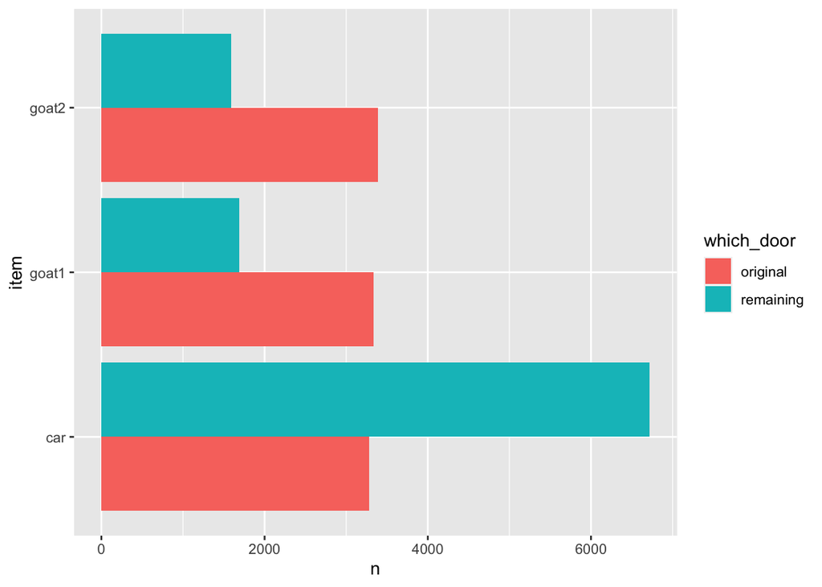

```r
ggplot(stuck_together, aes(x = item, y = n, fill = which_door)) +
  geom_bar(position="dodge", stat = "identity") +
  coord_flip()
```

Notice how the three reddish bars are almost equal – the original choice is equally likely to be any of the three available items. But the cyan bar corresponding to `Car` is twice as long as the red.

The simulation confirms that the contestant is twice as likely to win if she switches!

## Finding Probabilities

Over the centuries, there has been considerable philosophical debate about what probabilities are. Some people think that probabilities are relative frequencies; others think they are long run relative frequencies; still others think that probabilities are a subjective measure of their own personal degree of uncertainty.

In this course, most probabilities will be relative frequencies, though many will have subjective interpretations. Regardless, the ways in which probabilities are calculated and combined are consistent across the different interpretations.

By convention, probabilities are numbers between 0 and 1, or, equivalently, 0% and 100%. Impossible events have probability 0. Events that are certain have probability 1.

Math is the main tool for finding probabilities exactly, though computers are useful for this purpose too. Simulation can provide excellent approximations, with high probability. In this section, we will informally develop a few simple rules that govern the calculation of probabilities. In subsequent sections we will return to simulations to approximate probabilities of complex events.

We will use the standard notation $P(event)$ to denote the probability that “event” happens, and we will use the words “chance” and “probability” interchangeably.

### Prerequisites

As usual, we will make use of the tidyverse.

```r
library(tidyverse)
```

### When an Event Doesn’t Happen

If the chance that event happens is 40%, then the chance that it doesn’t happen is 60%. This natural calculation can be described in general as follows:

$$P(\text{an event doesn't happen}) =
1 - P(\text{the event happens})$$

### When All Outcomes are Equally Likely

If you are rolling an ordinary die, a natural assumption is that all six faces are equally likely. Then probabilities of how one roll comes out can be easily calculated as a ratio. For example, the chance that the die shows an even number is

$$\frac{\text{number of even
faces}}{\text{number of all faces}} =
\frac{\#\{2,4,6\}}{\#\{1,2,3,4,5,6\} } = \frac{3}{6}$$

Similarly,

$$P(\text{die shows a multiple of 3}) =
\frac{\#\{3, 6\}}{\#\{1,2,3,4,5,6\} } = \frac{2}{6}$$

In general,

$$P(\text{an event happens}) =
\frac{\#\{\text{outcomes that make the event happen}\}}{\#\{\text{all
outcomes}\} }$$

provided all the outcomes are equally likely.

Not all random phenomena are as simple as one roll of a die. The two main rules of probability, developed below, allow mathematicians to find probabilities even in complex situations.

### When Two Events Must Both Happen

Suppose you have a box that contains three tickets: one red, one blue, and one green. Suppose you draw two tickets at random without replacement; that is, you shuffle the three tickets, draw one, shuffle the remaining two, and draw another from those two. What is the chance you get the green ticket first, followed by the red one?

There are six possible pairs of colors: RB, BR, RG, GR, BG, GB (we’ve abbreviated the names of each color to just its first letter). All of these are equally likely by the sampling scheme, and only one of them (GR) makes the event happen. So

$$P(\text{green first, then red}) =
\frac{\#\{\text{GR}\}}{\#\{\text{RB, BR, RG, GR, BG, GB}\} } =
\frac{1}{6}$$

But there is another way of arriving at the answer, by thinking about the event in two stages. First, the green ticket has to be drawn. That has chance $1/3$, which means that the green ticket is drawn first in about $1/3$ of all repetitions of the experiment. But that doesn’t complete the event. *Among the 1/3 of repetitions when green is drawn first*, the red ticket has to be drawn next. That happens in about $1/2$ of those repetitions, and so:

$$P(\text{green first, then red}) =
\frac{1}{2} \text{ of } \frac{1}{3} = \frac{1}{6}$$

This calculation is usually written “in chronological order,” as follows.

$$P(\text{green first, then red}) =
\frac{1}{2} \text{ × } \frac{1}{3} = \frac{1}{6}$$

The factor of $1/2$ is called “the conditional chance that the red ticket appears second, given that the green ticket appeared first.”

In general, we have the **multiplication rule**:

$$P(\text{two events both happen})$$
$$= P(\text{one event happens}) ×
P(\text{the other event happens, given that the first one happened})$$

Thus, when there are two conditions – one event must happen, as well as another – the chance is a *fraction of a fraction*, which is smaller than either of the two component fractions. The more conditions that have to be satisfied, the less likely they are to all be satisfied.

### When an Event Can Happen in Two Different Ways

Suppose instead we want the chance that one of the two tickets is green and the other red. This event doesn’t specify the order in which the colors must appear. So they can appear in either order.

A good way to tackle problems like this is to partition the event so that it can happen in exactly one of several different ways. The natural partition of “one green and one red” is: GR, RG.

Each of GR and RG has chance $1/6$ by the calculation above. So you can calculate the chance of “one green and one red” by adding them up.

$$P(\text{one green and one red}) =
P(\text{GR}) + P(\text{RG}) = \frac{1}{6} + \frac{1}{6} = \frac{2}{6}$$

In general, we have the **addition rule**:

$$P(\text{an event happens}) =
P(\text{first way it can happen}) + P(\text{second way it can
happen})$$

provided the event happens in exactly one of the two ways.

Thus, when an event can happen in one of two different ways, the chance that it happens is a sum of chances, and hence bigger than the chance of either of the individual ways.

The multiplication rule has a natural extension to more than two events, as we will see below. So also the addition rule has a natural extension to events that can happen in one of several different ways.

We end the section with examples that use combinations of all these rules.

### At Least One Success

Data scientists often work with random samples from populations. A question that sometimes arises is about the likelihood that a particular individual in the population is selected to be in the sample. To work out the chance, that individual is called a “success,” and the problem is to find the chance that the sample contains a success.

To see how such chances might be calculated, we start with a simpler setting: tossing a coin two times.

If you toss a coin twice, there are four equally likely outcomes: HH, HT, TH, and TT. We have abbreviated “Heads” to H and “Tails” to T. The chance of getting at least one head in two tosses is therefore 3/4.

Another way of coming up with this answer is to work out what happens if you *don’t* get at least one head: both the tosses have to land tails. So

$$P(\text{at least one head in two
tosses}) = 1 - P(\text{both tails}) = 1 - \frac{1}{4} =
\frac{3}{4}$$

Notice also that

$$P(\text{both tails}) = \frac{1}{4} =
\frac{1}{2} * \frac{1}{2} = (\frac{1}{2})^2$$

by the multiplication rule.

These two observations allow us to find the chance of at least one head in any given number of tosses. For example,

$$P(\text{at least one head in 17 tosses})
= 1 - P(\text{all 17 are tails}) = 1 - (\frac{1}{2})^{17}$$

And now we are in a position to find the chance that the face with six spots comes up at least once in rolls of a die.

For example,

$$P(\text{a single roll is not 6}) = P(1)
+ P(2) + P(3) + P(4) + P(5) = \frac{5}{6}$$

Therefore,

$$P(\text{at least one 6 in two rolls}) =
1 - P(\text{both rolls are not 6}) = 1 - (\frac{5}{6})^2$$

and

$$P(\text{at least one 6 in 17 rolls}) = 1
- (\frac{5}{6})^{17}$$

```r
rolls <- 1:51
results <- tibble(rolls = rolls,
                  prob_of_at_least_one_six = 1 - (5/6) ** rolls)
results
```

```
## # A tibble: 51 × 2
##    rolls prob_of_at_least_one_six
##    <int>                    <dbl>
##  1     1                    0.167
##  2     2                    0.306
##  3     3                    0.421
##  4     4                    0.518
##  5     5                    0.598
##  6     6                    0.665
##  7     7                    0.721
##  8     8                    0.767
##  9     9                    0.806
## 10    10                    0.838
## # ℹ 41 more rows
```

The chance that a 6 appears at least once rises rapidly as the number of rolls increases.

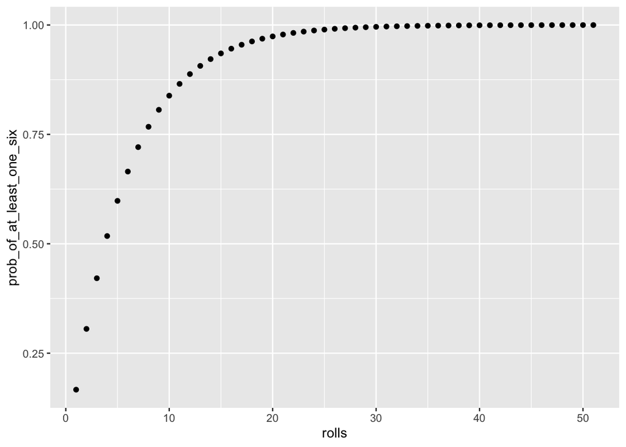

```r
ggplot(results) +
  geom_point(aes(x = rolls, y = prob_of_at_least_one_six))
```

In 50 rolls, you are almost certain to get at least one 6.

```r
filter(results, rolls == 50) |> as.data.frame()
```

```
##   rolls prob_of_at_least_one_six
## 1    50                0.9998901
```

If you have ever played games that rely heavily on “RNG” (*r*andom *n*umber *g*enerator), chances are you intuitively exploited this finding: just keep “rolling” until you find that rare item!

Calculations like these can be used to find the chance that a particular individual is selected in a random sample. The exact calculation will depend on the sampling scheme. But what we have observed above can usually be generalized: increasing the size of the random sample increases the chance that an individual is selected.